# 02-Pointing_gestures_and_common_ground_logistic_regression

Olena Tykhostup

2022-01-29

This is the code used for data analysis reported in Chapter 6 of the dissertation titled ‘Multimodal Annotation and Analysis of a Narrative Problem-Solving Task in English, Idi, and Russian’. This script is sequence of statistical analyses and visualizations focusing on pointing gesture phases (sroke and hold), effort (contact and no contact with the target during the pointing ggesture), and hand shape (open palm and index finger) in pointing gestures, across three languages (English, Russian, and Idi) on the one hand, and the annotations of information status of co-produced spoken expressions, on the other. Specifically, this code runs a series of logistic regression models. It includes model fitting with both fixed effects and random intercepts for speakers, model comparisons to determine the best fit, and visualizations of predicted probabilities.

## Load the packages

```r
library(here)
library(lubridate)
library(ggplot2)
library(tidyverse)
library(sjPlot) # for tab_model and plot_model functions
library(lme4)
library(ggeffects)
library(gtable)
library(performance)
```

## Define the color palette

```r
customColors <- c("#183A5A", "#EFB758", "#C34129", "#E2DBC9")
```

## Load the data

English, Idi, Russian data samples, both experiment phases.

```r
pointCommonGroundData <- read.csv(here("data", "FPPT-EIR-Full-Annotations.csv"))
```

## Prepare the data for analysis

```r
cleanDataForAnalysis <- pointCommonGroundData %>%
  mutate_at(vars(begin, end), ~ as.POSIXct(., format = "%Y-%m-%dT%H:%M:%SZ")) %>% # transform time columns to POSIXct
  mutate_at(vars(speaker, trial, affil, infstat, shape, effort, traj, orient, target, cards, lang, phase),funs(factor(.))) %>% # transform all columns into factors (card stays character)
  mutate(affwords = str_count(coart, fixed(".")),
         affwords = as.integer(affwords + 1))  # a column that contains number of words in affiliate
```

## Inspect the df

```r
str(cleanDataForAnalysis)
```

```
## 'data.frame':    1449 obs. of  17 variables:
##  $ speaker : Factor w/ 16 levels "FPPTER106","FPPTER107",..: 1 1 1 1 1 1 1 1 1 1 ...
##  $ begin   : POSIXct, format: "2024-01-09 23:15:04" "2024-01-09 23:17:30" ...
##  $ end     : POSIXct, format: "2024-01-09 23:15:05" "2024-01-09 23:17:32" ...
##  $ dur     : int  555 1712 1068 3885 1295 595 455 555 3160 1030 ...
##  $ trial   : Factor w/ 14 levels "FPPT-ENG-Phase1-20181219-v7-ALS-v1.eaf",..: 1 1 1 1 1 1 1 1 1 1 ...
##  $ coart   : chr  "he.s.got.a.drink.in.his.hand" "he.goes.to.jail" "that.s.him" "walking.back" ...
##  $ affil   : Factor w/ 4 levels "ambiguous","noun",..: 1 1 4 3 4 3 3 3 3 3 ...
##  $ infstat : Factor w/ 3 levels "new","old","other": 2 2 2 2 3 1 3 3 3 3 ...
##  $ shape   : Factor w/ 3 levels "index","other",..: 1 1 1 1 3 3 1 1 1 1 ...
##  $ effort  : Factor w/ 2 levels "contact","nocontact": 2 2 2 1 1 1 1 1 1 1 ...
##  $ traj    : Factor w/ 2 levels "complex","simple": 2 2 2 2 2 2 2 2 2 2 ...
##  $ orient  : Factor w/ 3 levels "down","up","vertical": 1 3 1 1 1 1 1 1 1 1 ...
##  $ target  : Factor w/ 4 levels "card","individ",..: 3 3 3 2 1 1 1 1 1 1 ...
##  $ cards   : Factor w/ 2 levels "multiple","single": 2 1 1 1 1 1 1 1 1 1 ...
##  $ lang    : Factor w/ 3 levels "eng","idi","rus": 1 1 1 1 1 1 1 1 1 1 ...
##  $ phase   : Factor w/ 2 levels "H","S": 2 2 2 1 1 2 2 2 1 2 ...
##  $ affwords: int  8 4 3 2 1 1 1 1 1 1 ...
```

```r
summary(cleanDataForAnalysis)
```

```
##       speaker        begin
##  FPPTRR202:207   Min.   :2024-01-09 23:00:09.00
##  FPPTRR303:205   1st Qu.:2024-01-09 23:04:14.00
##  FPPTER201:168   Median :2024-01-09 23:08:02.00
##  FPPTIR101:167   Mean   :2024-01-09 23:09:34.64
##  FPPTRR105:130   3rd Qu.:2024-01-09 23:13:42.00
##  FPPTRR307:117   Max.   :2024-01-09 23:33:31.00
##  (Other)  :455
##       end                             dur
##  Min.   :2024-01-09 23:00:11.0   Min.   :  150
##  1st Qu.:2024-01-09 23:04:15.0   1st Qu.:  803
##  Median :2024-01-09 23:08:03.0   Median : 1220
##  Mean   :2024-01-09 23:09:36.2   Mean   : 1542
##  3rd Qu.:2024-01-09 23:13:44.0   3rd Qu.: 1884
##  Max.   :2024-01-09 23:33:32.0   Max.   :16982
##
##                                     trial        coart
##  FPPT-RUS-Phase1-20181213-v7.eaf       :247   Length:1449
##  FPPT-ENG-Phase1-20190213-v6-ALS-v1.eaf:234   Class :character
##  FPPT-RUS-Phase1-20181211-v5.eaf       :171   Mode  :character
##  FPPT-IDI-Phase1-20200626-v2.eaf       :167
##  FPPT-RUS-Phase1-20181206-v5.eaf       :140
##  FPPT-ENG-Phase1-20191112-v8-ALS-v1.eaf:119
##  (Other)                               :371
##        affil      infstat      shape            effort         traj
##  ambiguous:410   new  :722   index:1054   contact  :740   complex:490
##  noun     :484   old  :617   other: 129   nocontact:709   simple :959
##  other    :222   other:110   palm : 266
##  pro      :333
##
##
##
##       orient          target         cards      lang     phase
##  down    :1075   card    :355   multiple:712   eng:500   H: 413
##  up      : 138   individ :569   single  :737   idi:167   S:1036
##  vertical: 236   interior:470                  rus:782
##                  other   : 55
##
##
##
##     affwords
##  Min.   : 1.00
##  1st Qu.: 1.00
##  Median : 3.00
##  Mean   : 3.05
##  3rd Qu.: 4.00
##  Max.   :21.00
##
```

```r
sum(is.na(cleanDataForAnalysis))
```

```
## [1] 0
```

## Binomial Logistic Regression for gesture phase

## gesture either contains a hold phase “H” or only a stroke phase “S”

```r
phaseDataEng <- cleanDataForAnalysis %>%
  filter(infstat!= "other") %>%
  filter(lang=="eng") %>%
  select(speaker, phase, infstat)
```

## Fixed-effects minimal base-line model vs a base-line mixed-model using the glmer function with a random intercept for speaker

AIC of the glmer model is smaller than the AIC of the glm model, indicating that including random intercepts is justified.

```r
# baseline model glm
baseModelPhaseEng <- glm(phase ~ 1, family = binomial, data = phaseDataEng)
# base-line mixed-model
mixedModelPhaseSpeakerEng <- glmer(phase ~ (1|speaker), data = phaseDataEng, family = binomial())

AIC(baseModelPhaseEng, mixedModelPhaseSpeakerEng)
```

```
##                           df      AIC
## baseModelPhaseEng          1 553.5769
## mixedModelPhaseSpeakerEng  2 546.6844
```

## Model and summary English gesture phase

```r
mixedModelPhaseInfStatusSpeakerEng <- glmer(phase ~ infstat + (1|speaker), data = phaseDataEng, family = binomial())

summary(mixedModelPhaseInfStatusSpeakerEng)
```

```
## Generalized linear mixed model fit by maximum likelihood (Laplace
##   Approximation) [glmerMod]
##  Family: binomial  ( logit )
## Formula: phase ~ infstat + (1 | speaker)
##    Data: phaseDataEng
##
##      AIC      BIC   logLik deviance df.resid
##    530.8    542.9   -262.4    524.8      419
##
## Scaled residuals:
##     Min      1Q  Median      3Q     Max
## -2.2154 -1.0550  0.5041  0.7712  1.5023
##
## Random effects:
##  Groups  Name        Variance Std.Dev.
##  speaker (Intercept) 0.3106   0.5573
## Number of obs: 422, groups:  speaker, 8
##
## Fixed effects:
##             Estimate Std. Error z value Pr(>|z|)
## (Intercept)   0.1772     0.2584   0.686    0.493
## infstatold    0.9211     0.2232   4.127 3.67e-05 ***
## ---
## Signif. codes:  0 '***' 0.001 '**' 0.01 '*' 0.05 '.' 0.1 ' ' 1
##
## Correlation of Fixed Effects:
##            (Intr)
## infstatold -0.359
```

```r
sjPlot::tab_model(mixedModelPhaseInfStatusSpeakerEng)
```

|  | phase |  |  |
| --- | --- | --- | --- |
| Predictors | Odds Ratios | CI | p |
| (Intercept) | 1.19 | 0.72 – 1.98 | 0.493 |
| infstat [old] | 2.51 | 1.62 – 3.89 | **<0.001** |
| Random Effects |  |  |  |
| σ<sup>2</sup> | 3.29 |  |  |
| τ<sub>00</sub> <sub>speaker</sub> | 0.31 |  |  |
| ICC | 0.09 |  |  |
| N <sub>speaker</sub> | 8 |  |  |
| Observations | 422 |  |  |
| Marginal R<sup>2</sup> / Conditional R<sup>2</sup> | 0.056 / 0.137 |  |  |

## Compare to 0 model

```r
anova(mixedModelPhaseInfStatusSpeakerEng, mixedModelPhaseSpeakerEng, test = "Chi")
```

```
## Data: phaseDataEng
## Models:
## mixedModelPhaseSpeakerEng: phase ~ (1 | speaker)
## mixedModelPhaseInfStatusSpeakerEng: phase ~ infstat + (1 | speaker)
##                                    npar    AIC    BIC  logLik deviance  Chisq
## mixedModelPhaseSpeakerEng             2 546.68 554.77 -271.34   542.68
## mixedModelPhaseInfStatusSpeakerEng    3 530.78 542.91 -262.39   524.78 17.909
##                                    Df Pr(>Chisq)
## mixedModelPhaseSpeakerEng
## mixedModelPhaseInfStatusSpeakerEng  1  2.317e-05 ***
## ---
## Signif. codes:  0 '***' 0.001 '**' 0.01 '*' 0.05 '.' 0.1 ' ' 1
```

## Visualize effects and run diagnostics

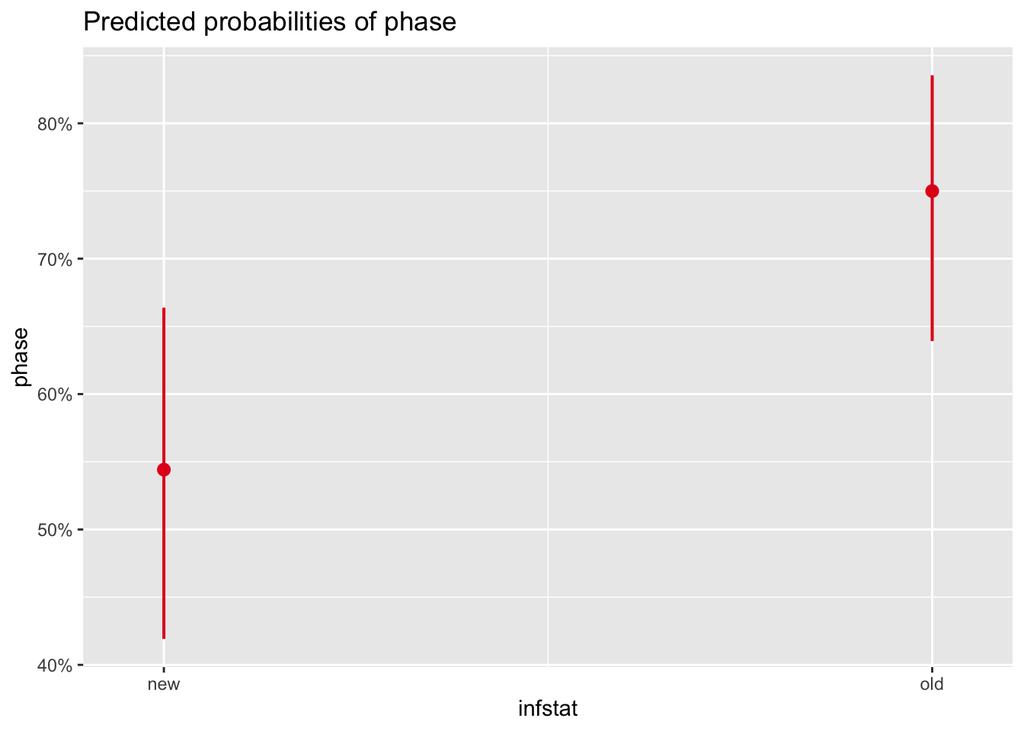

```r
# Predicted probabilities of poinitng gesture not including the hold phase
plot_model(mixedModelPhaseInfStatusSpeakerEng, type = "pred", terms = "infstat")
```

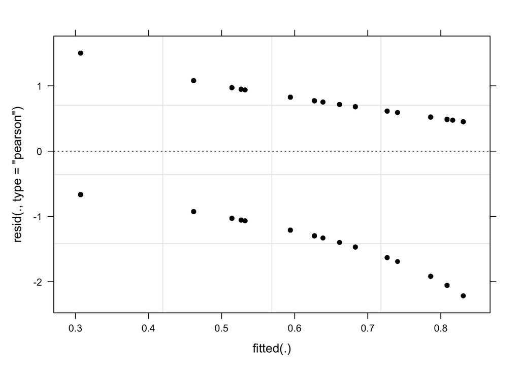

```r
# the predicted values against the residuals
plot(mixedModelPhaseInfStatusSpeakerEng, pch = 20, col = "black", lty = "dotted")
```

## Russian poinitng gesture phase df

```r
phaseDataRus <- cleanDataForAnalysis %>%
  filter(infstat!= "other") %>%
  filter(lang=="rus") %>%
  select(speaker, phase, infstat)
```

## Fixed-effects minimal base-line model vs a base-line mixed-model using the glmer function with a random intercept for speaker

AIC of the glmer model is smaller than the AIC of the glm model, indicating that including random intercepts is justified.

```r
# baseline model glm
baseModelPhaseRus <- glm(phase ~ 1, family = binomial, data = phaseDataRus)
# base-line mixed-model
mixedModelPhaseSpeakerRus <- glmer(phase ~ (1|speaker), data = phaseDataRus, family = binomial())

AIC(baseModelPhaseRus, mixedModelPhaseSpeakerRus)
```

```
##                           df      AIC
## baseModelPhaseRus          1 875.8919
## mixedModelPhaseSpeakerRus  2 861.8547
```

## Model and summary Russian gesture phase

```r
mixedModelPhaseInfStatusSpeakerRus <- glmer(phase ~ infstat + (1|speaker), data = phaseDataRus, family = binomial())
levels(phaseDataRus$phase)
```

```
## [1] "H" "S"
```

```r
summary(mixedModelPhaseInfStatusSpeakerRus)
```

```
## Generalized linear mixed model fit by maximum likelihood (Laplace
##   Approximation) [glmerMod]
##  Family: binomial  ( logit )
## Formula: phase ~ infstat + (1 | speaker)
##    Data: phaseDataRus
##
##      AIC      BIC   logLik deviance df.resid
##    780.8    794.6   -387.4    774.8      747
##
## Scaled residuals:
##     Min      1Q  Median      3Q     Max
## -3.6382 -0.8864  0.3499  0.6503  1.1281
##
## Random effects:
##  Groups  Name        Variance Std.Dev.
##  speaker (Intercept) 0.3416   0.5845
## Number of obs: 750, groups:  speaker, 7
##
## Fixed effects:
##             Estimate Std. Error z value Pr(>|z|)
## (Intercept)   0.3736     0.2576   1.450    0.147
## infstatold    1.7126     0.2062   8.307   <2e-16 ***
## ---
## Signif. codes:  0 '***' 0.001 '**' 0.01 '*' 0.05 '.' 0.1 ' ' 1
##
## Correlation of Fixed Effects:
##            (Intr)
## infstatold -0.190
```

```r
sjPlot::tab_model(mixedModelPhaseInfStatusSpeakerRus)
```

|  | phase |  |  |
| --- | --- | --- | --- |
| Predictors | Odds Ratios | CI | p |
| (Intercept) | 1.45 | 0.88 – 2.41 | 0.147 |
| infstat [old] | 5.54 | 3.70 – 8.30 | **<0.001** |
| Random Effects |  |  |  |
| σ<sup>2</sup> | 3.29 |  |  |
| τ<sub>00</sub> <sub>speaker</sub> | 0.34 |  |  |
| ICC | 0.09 |  |  |
| N <sub>speaker</sub> | 7 |  |  |
| Observations | 750 |  |  |
| Marginal R<sup>2</sup> / Conditional R<sup>2</sup> | 0.166 / 0.245 |  |  |

## Subset and fit Idi model for pointing gesture phase

```r
phaseDataIdi <- cleanDataForAnalysis %>%
  filter(lang=="idi") %>%
  filter(infstat!="other")

modelPhaseInfStatIdi <- glm(phase ~ infstat, data = phaseDataIdi, family = "binomial")

summary(modelPhaseInfStatIdi)
```

```
##
## Call:
## glm(formula = phase ~ infstat, family = "binomial", data = phaseDataIdi)
##
## Coefficients:
##             Estimate Std. Error z value Pr(>|z|)
## (Intercept)   1.0076     0.2436   4.136 3.53e-05 ***
## infstatold    0.9525     0.4165   2.287   0.0222 *
## ---
## Signif. codes:  0 '***' 0.001 '**' 0.01 '*' 0.05 '.' 0.1 ' ' 1
##
## (Dispersion parameter for binomial family taken to be 1)
##
##     Null deviance: 166.02  on 166  degrees of freedom
## Residual deviance: 160.43  on 165  degrees of freedom
## AIC: 164.43
##
## Number of Fisher Scoring iterations: 4
```

```r
sjPlot::tab_model(modelPhaseInfStatIdi)
```

|  | phase |  |  |
| --- | --- | --- | --- |
| Predictors | Odds Ratios | CI | p |
| (Intercept) | 2.74 | 1.73 – 4.51 | **<0.001** |
| infstat [old] | 2.59 | 1.17 – 6.09 | **0.022** |
| Observations | 167 |  |  |
| R<sup>2</sup> Tjur | 0.033 |  |  |

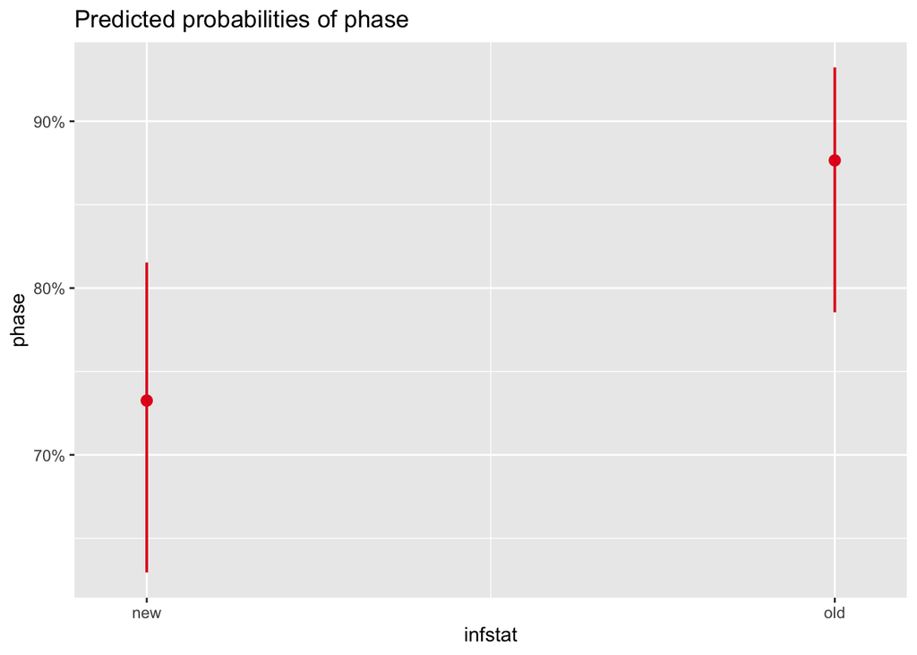

```r
plot_model(modelPhaseInfStatIdi, type = "pred", terms = "infstat")
```

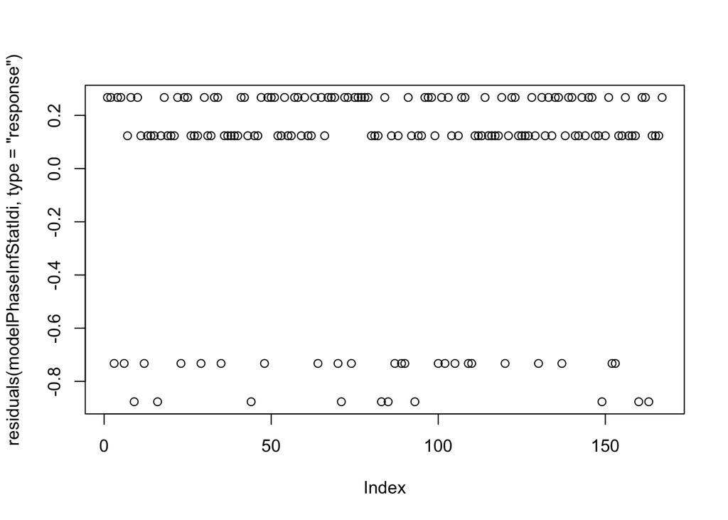

```r
plot(residuals(modelPhaseInfStatIdi, type = "response"))
```

## Make ggplot for pointing gesture phase with all three models

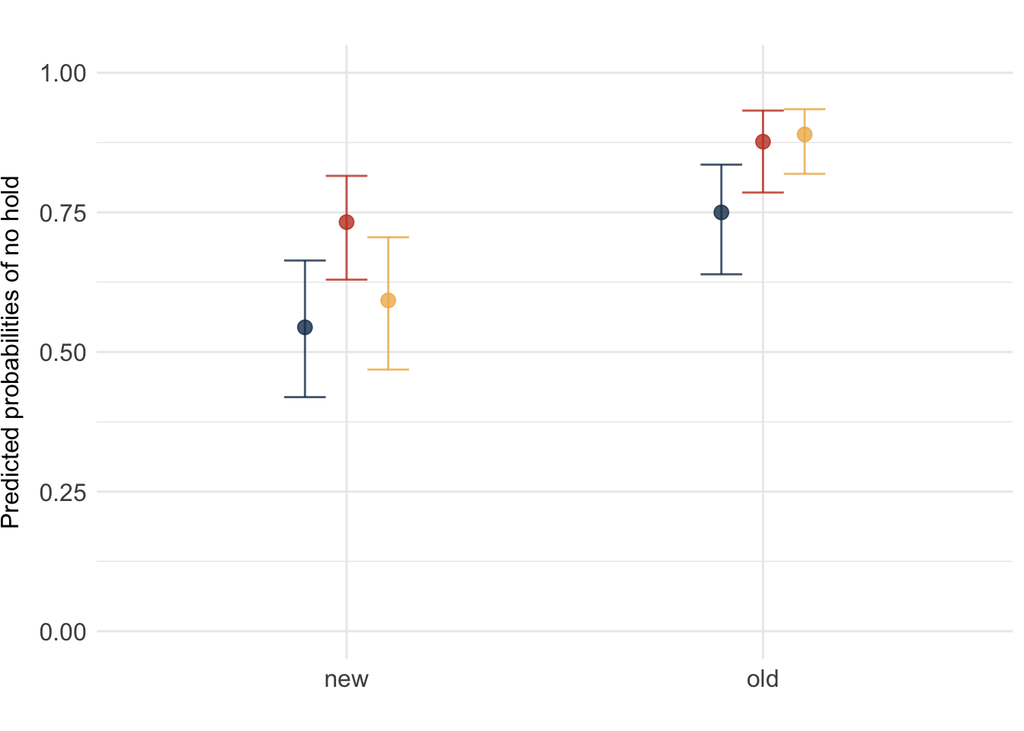

```r
plotModelPhaseIdi <- ggpredict(modelPhaseInfStatIdi, "infstat") %>% as.data.frame()
plotModelPhaseEng <- ggpredict(mixedModelPhaseInfStatusSpeakerEng, "infstat") %>% as.data.frame()
plotModelPhaseRus <- ggpredict(mixedModelPhaseInfStatusSpeakerRus, "infstat")%>% as.data.frame()

plotPredProbPhaseEngIdiRus <- ggplot(plotModelPhaseEng, aes(x, predicted)) +
  geom_errorbar(aes(ymin=conf.low, ymax=conf.high, color="#183A5A"), width=.1, alpha = 0.8,  position = position_nudge(x = -0.1)) + # English errorbar
  geom_point(aes(color="#183A5A"), size = 3, alpha = 0.8,  position = position_nudge(x = -0.1)) + # blue color
  geom_errorbar(data=plotModelPhaseRus, aes(ymin=conf.low, ymax=conf.high, color="#EFB758"), width=.1, alpha = 0.8,  position = position_nudge(x = 0.1)) + # Russian errorbar
  geom_point(data=plotModelPhaseRus, aes(colour = "#EFB758"), size = 3, alpha = 0.8, position = position_nudge(x = 0.1)) + # yellow color
  geom_errorbar(data=plotModelPhaseIdi, aes(ymin=conf.low, ymax=conf.high, color="#C34129"), width=.1, alpha = 0.8) + # Idi errorbar
  geom_point(data=plotModelPhaseIdi, aes(colour = "#C34129"), size = 3, alpha = 0.8) + # red color
  coord_cartesian(ylim=c(0, 1)) +
  theme_minimal() +
  labs(x="", y="Predicted probabilities of no hold", title = "") +
  scale_color_identity(name = "Languages:",
                       breaks = c("#183A5A", "#C34129", "#EFB758"),
                       labels = c("English", "Idi", "Russian"),
                       guide = "legend") +
  theme(axis.title = element_text(size=12),
        axis.title.y = element_text(vjust=3),
        axis.text = element_text(size=12),
        plot.title = element_text(size=12, hjust = 0.5),
        legend.text = element_text(size=12),
        legend.title = element_text(size=12),
        legend.position = "none") +
  guides(color = guide_legend(ncol = 3))

plotPredProbPhaseEngIdiRusLegend <- plotPredProbPhaseEngIdiRus +
  theme(legend.position = "bottom")

# Render the plot and extract the legend
plotPredProbPhaseEngIdiRusBuild <- ggplot_build(plotPredProbPhaseEngIdiRusLegend)
predProbPhaseEngIdiRusGtable <- ggplot_gtable(plotPredProbPhaseEngIdiRusBuild)
legendPhaseEngIdiRus <- gtable_filter(predProbPhaseEngIdiRusGtable, "guide-box")

plotPredProbPhaseEngIdiRus
```

## Save as figures

```r
# Save the legend as a PDF
ggsave(here("figures", "FPPT-Point-legend-thee-lang.pdf"), plot = legendPhaseEngIdiRus, width = 5, height = 0.5, units = "in")

# Save figure as PNG
png(here("figures", "FPPT-Point-phase-thee-lang.png"),  width = 7.5, height = 9, units = "cm", res = 500)
plotPredProbPhaseEngIdiRus
dev.off()
```

```r
# as PDF
pdf(here("figures", "FPPT-Point-phase-thee-lang.pdf"),  width = 3.5, height = 4)
plotPredProbPhaseEngIdiRus
dev.off()
```

## Regression modelling for effort

Effort is operationalized as contact of the pointing gesture with the target or absence of contact (“contact” and “nocontact”) ## Subset English data for effort variable (contact vs no contact)

```r
effortDataEng <- cleanDataForAnalysis %>%
  filter(infstat!= "other") %>%
  filter(lang=="eng") %>%
  select(speaker, effort, infstat)
```

## Fixed-effects minimal base-line model vs a base-line mixed-model using the glmer function with a random intercept for speaker

AIC of the glmer model is smaller than the AIC of the glm model, indicating that including random intercepts is justified.

```r
# baseline model glm
baseModelEffortEng <- glm(effort ~ 1, family = binomial, data = effortDataEng)
# base-line mixed-model
mixeModelEffortSpeakerEng <- glmer(effort ~ (1|speaker), data = effortDataEng, family = binomial())

AIC(baseModelEffortEng, mixeModelEffortSpeakerEng)
```

```
##                           df      AIC
## baseModelEffortEng         1 585.6506
## mixeModelEffortSpeakerEng  2 564.6800
```

## Model and summary

```r
mixeModelEffortInfStatSpeakerEng <- glmer(effort ~ infstat + (1|speaker), data = effortDataEng, family = binomial())

summary(mixeModelEffortInfStatSpeakerEng)
```

```
## Generalized linear mixed model fit by maximum likelihood (Laplace
##   Approximation) [glmerMod]
##  Family: binomial  ( logit )
## Formula: effort ~ infstat + (1 | speaker)
##    Data: effortDataEng
##
##      AIC      BIC   logLik deviance df.resid
##    389.9    402.0   -192.0    383.9      419
##
## Scaled residuals:
##     Min      1Q  Median      3Q     Max
## -4.1022 -0.3789 -0.3417  0.5563  2.9269
##
## Random effects:
##  Groups  Name        Variance Std.Dev.
##  speaker (Intercept) 0.4912   0.7009
## Number of obs: 422, groups:  speaker, 8
##
## Fixed effects:
##             Estimate Std. Error z value Pr(>|z|)
## (Intercept)  -1.5440     0.3270  -4.722 2.33e-06 ***
## infstatold    3.1138     0.2738  11.372  < 2e-16 ***
## ---
## Signif. codes:  0 '***' 0.001 '**' 0.01 '*' 0.05 '.' 0.1 ' ' 1
##
## Correlation of Fixed Effects:
##            (Intr)
## infstatold -0.414
```

```r
sjPlot::tab_model(mixeModelEffortInfStatSpeakerEng)
```

|  | effort |  |  |
| --- | --- | --- | --- |
| Predictors | Odds Ratios | CI | p |
| (Intercept) | 0.21 | 0.11 – 0.41 | **<0.001** |
| infstat [old] | 22.51 | 13.16 – 38.49 | **<0.001** |
| Random Effects |  |  |  |
| σ<sup>2</sup> | 3.29 |  |  |
| τ<sub>00</sub> <sub>speaker</sub> | 0.49 |  |  |
| ICC | 0.13 |  |  |
| N <sub>speaker</sub> | 8 |  |  |
| Observations | 422 |  |  |
| Marginal R<sup>2</sup> / Conditional R<sup>2</sup> | 0.391 / 0.470 |  |  |

## Compare to other models

There a better fit of the more complex model (with information status) compared to the ssimpler model (without it).

```r
anova(mixeModelEffortInfStatSpeakerEng, mixeModelEffortSpeakerEng, test="Chi")
```

```
## Data: effortDataEng
## Models:
## mixeModelEffortSpeakerEng: effort ~ (1 | speaker)
## mixeModelEffortInfStatSpeakerEng: effort ~ infstat + (1 | speaker)
##                                  npar    AIC    BIC  logLik deviance  Chisq Df
## mixeModelEffortSpeakerEng           2 564.68 572.77 -280.34   560.68
## mixeModelEffortInfStatSpeakerEng    3 389.91 402.05 -191.96   383.91 176.77  1
##                                  Pr(>Chisq)
## mixeModelEffortSpeakerEng
## mixeModelEffortInfStatSpeakerEng  < 2.2e-16 ***
## ---
## Signif. codes:  0 '***' 0.001 '**' 0.01 '*' 0.05 '.' 0.1 ' ' 1
```

```r
compare_performance(mixeModelEffortSpeakerEng, mixeModelEffortInfStatSpeakerEng)
```

```
## # Comparison of Model Performance Indices
##
## Name                             |    Model | AIC (weights) | AICc (weights) | BIC (weights) | R2 (cond.) | R2 (marg.) |   ICC |  RMSE | Sigma | Log_loss | Score_log | Score_spherical
## ---------------------------------------------------------------------------------------------------------------------------------------------------------------------------------------
## mixeModelEffortSpeakerEng        | glmerMod | 564.7 (<.001) |  564.7 (<.001) | 572.8 (<.001) |      0.099 |      0.000 | 0.099 | 0.475 | 1.000 |    0.643 |  -132.270 |           0.017
## mixeModelEffortInfStatSpeakerEng | glmerMod | 389.9 (>.999) |  390.0 (>.999) | 402.0 (>.999) |      0.470 |      0.391 | 0.130 | 0.369 | 1.000 |    0.436 |  -184.353 |           0.008
```

## Visualize effects and run diagnostics

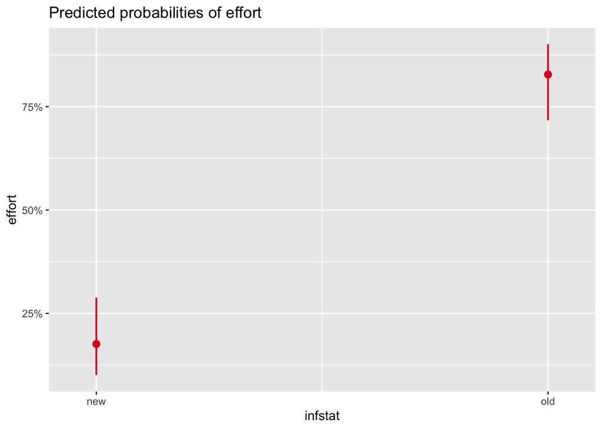

```r
# Predicted probabilities of poinitng gesture not including the hold phase
plot_model(mixeModelEffortInfStatSpeakerEng, type = "pred", terms = "infstat")
```

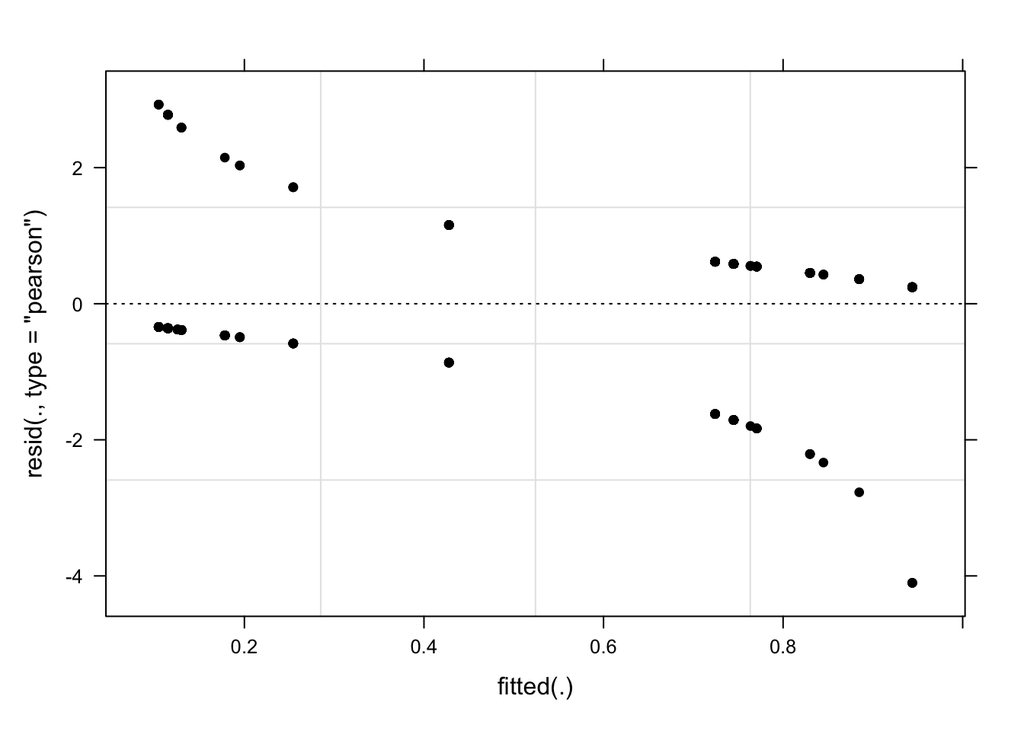

```r
# the predicted values against the residuals
plot(mixeModelEffortInfStatSpeakerEng, pch = 20, col = "black", lty = "dotted")
```

## Subset Russian data for effort variable (contact vs no contact)

```r
effortDataRus <- cleanDataForAnalysis %>%
  filter(infstat!= "other") %>%
  filter(lang=="rus") %>%
  select(speaker, effort, infstat)
```

## Fixed-effects minimal base-line model vs a base-line mixed-model using the glmer function with a random intercept for speaker

AIC of the glmer model is smaller than the AIC of the glm model, indicating that including random intercepts is justified.

```r
# baseline model glm
baseModelEffortRus <- glm(effort ~ 1, family = binomial, data = effortDataRus)
# base-line mixed-model
mixedModelEffortSpeakerRus <- glmer(effort ~ (1|speaker), data = effortDataRus, family = binomial())

AIC(baseModelEffortRus, mixedModelEffortSpeakerRus)
```

```
##                            df      AIC
## baseModelEffortRus          1 1040.953
## mixedModelEffortSpeakerRus  2 1029.406
```

## Model and summary

```r
mixedModelEffortInfStatusSpeakerRus <- glmer(effort ~ infstat + (1|speaker), data = effortDataRus, family = binomial())

summary(mixedModelEffortInfStatusSpeakerRus)
```

```
## Generalized linear mixed model fit by maximum likelihood (Laplace
##   Approximation) [glmerMod]
##  Family: binomial  ( logit )
## Formula: effort ~ infstat + (1 | speaker)
##    Data: effortDataRus
##
##      AIC      BIC   logLik deviance df.resid
##    574.6    588.5   -284.3    568.6      747
##
## Scaled residuals:
##     Min      1Q  Median      3Q     Max
## -3.9920 -0.4367 -0.2737  0.3134  3.6536
##
## Random effects:
##  Groups  Name        Variance Std.Dev.
##  speaker (Intercept) 0.2955   0.5436
## Number of obs: 750, groups:  speaker, 7
##
## Fixed effects:
##             Estimate Std. Error z value Pr(>|z|)
## (Intercept)  -1.9173     0.2711  -7.072 1.53e-12 ***
## infstatold    3.9775     0.2406  16.530  < 2e-16 ***
## ---
## Signif. codes:  0 '***' 0.001 '**' 0.01 '*' 0.05 '.' 0.1 ' ' 1
##
## Correlation of Fixed Effects:
##            (Intr)
## infstatold -0.375
```

```r
sjPlot::tab_model(mixedModelEffortInfStatusSpeakerRus)
```

|  | effort |  |  |
| --- | --- | --- | --- |
| Predictors | Odds Ratios | CI | p |
| (Intercept) | 0.15 | 0.09 – 0.25 | **<0.001** |
| infstat [old] | 53.39 | 33.31 – 85.55 | **<0.001** |
| Random Effects |  |  |  |
| σ<sup>2</sup> | 3.29 |  |  |
| τ<sub>00</sub> <sub>speaker</sub> | 0.30 |  |  |
| ICC | 0.08 |  |  |
| N <sub>speaker</sub> | 7 |  |  |
| Observations | 750 |  |  |
| Marginal R<sup>2</sup> / Conditional R<sup>2</sup> | 0.522 / 0.561 |  |  |

## Compare to 0 model

```r
anova(mixedModelEffortInfStatusSpeakerRus, mixedModelEffortSpeakerRus, test = "Chi")
```

```
## Data: effortDataRus
## Models:
## mixedModelEffortSpeakerRus: effort ~ (1 | speaker)
## mixedModelEffortInfStatusSpeakerRus: effort ~ infstat + (1 | speaker)
##                                     npar     AIC     BIC logLik deviance Chisq
## mixedModelEffortSpeakerRus             2 1029.41 1038.65 -512.7  1025.41
## mixedModelEffortInfStatusSpeakerRus    3  574.61  588.47 -284.3   568.61 456.8
##                                     Df Pr(>Chisq)
## mixedModelEffortSpeakerRus
## mixedModelEffortInfStatusSpeakerRus  1  < 2.2e-16 ***
## ---
## Signif. codes:  0 '***' 0.001 '**' 0.01 '*' 0.05 '.' 0.1 ' ' 1
```

## Visualize effects and run diagnostics

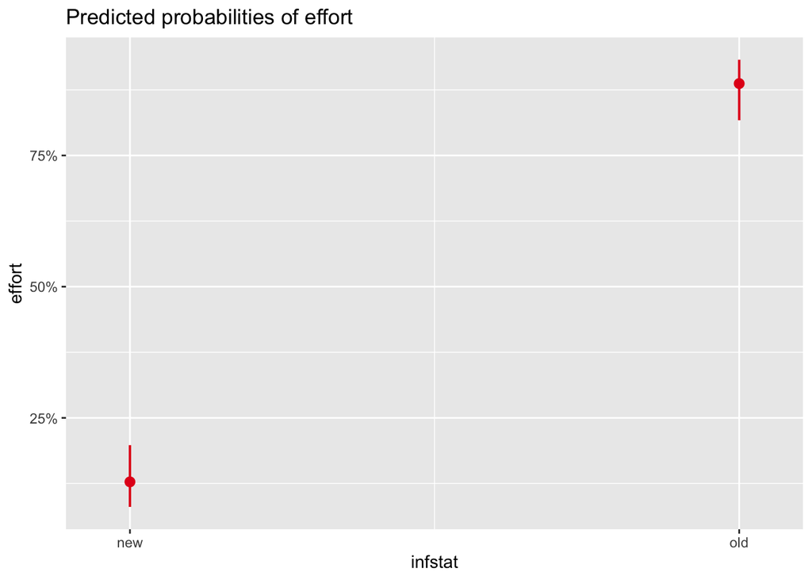

```r
# Predicted probabilities of poinitng gesture not touching the target
plot_model(mixedModelEffortInfStatusSpeakerRus, type = "pred", terms = "infstat")
```

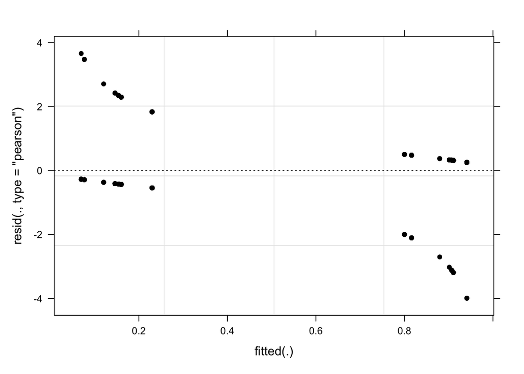

```r
# the predicted values against the residuals
plot(mixedModelEffortInfStatusSpeakerRus, pch = 20, col = "black", lty = "dotted")
```

## Subset and fit Idi model for pointing gesture effort

```r
modelEffortInfStatIdi <- glm(effort ~ infstat, data = phaseDataIdi, family = "binomial")

summary(modelEffortInfStatIdi)
```

```
##
## Call:
## glm(formula = effort ~ infstat, family = "binomial", data = phaseDataIdi)
##
## Coefficients:
##             Estimate Std. Error z value Pr(>|z|)
## (Intercept)  -1.4759     0.2771  -5.326 1.00e-07 ***
## infstatold    3.1305     0.4104   7.628 2.38e-14 ***
## ---
## Signif. codes:  0 '***' 0.001 '**' 0.01 '*' 0.05 '.' 0.1 ' ' 1
##
## (Dispersion parameter for binomial family taken to be 1)
##
##     Null deviance: 231.51  on 166  degrees of freedom
## Residual deviance: 153.99  on 165  degrees of freedom
## AIC: 157.99
##
## Number of Fisher Scoring iterations: 4
```

```r
sjPlot::tab_model(modelEffortInfStatIdi)
```

|  | effort |  |  |
| --- | --- | --- | --- |
| Predictors | Odds Ratios | CI | p |
| (Intercept) | 0.23 | 0.13 – 0.38 | **<0.001** |
| infstat [old] | 22.88 | 10.58 – 53.19 | **<0.001** |
| Observations | 167 |  |  |
| R<sup>2</sup> Tjur | 0.427 |  |  |

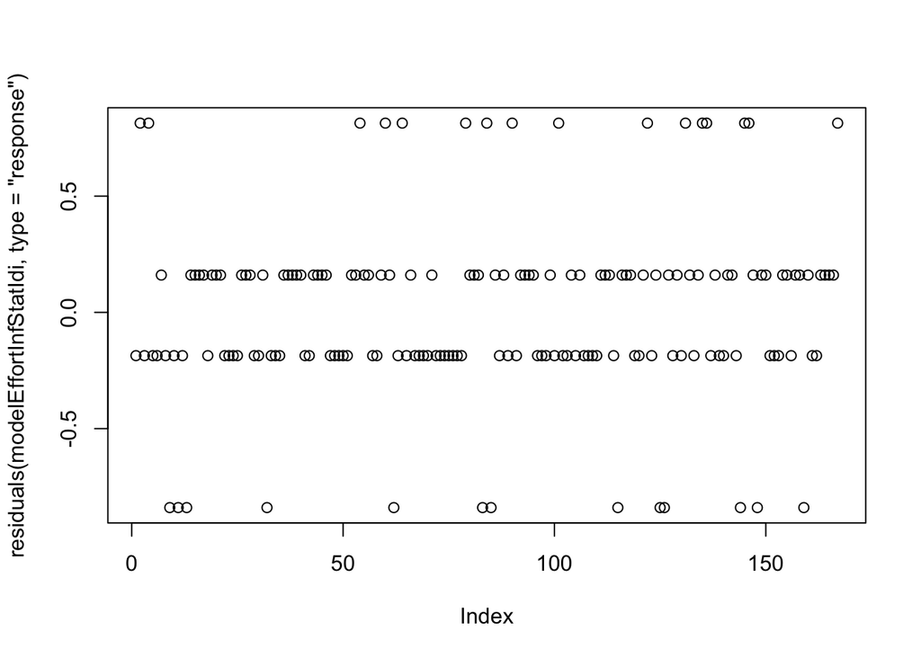

```r
plot(residuals(modelEffortInfStatIdi, type = "response"))
```

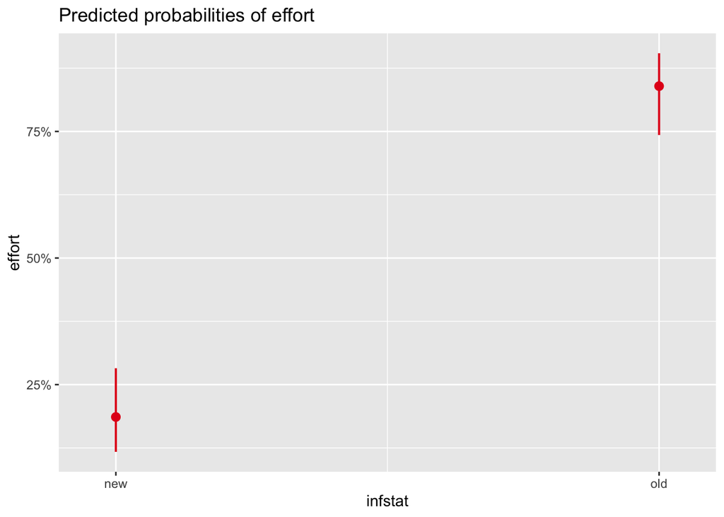

```r
plot_model(modelEffortInfStatIdi, type = "pred", terms = "infstat")
```

## Regression modelling for hand shape Two hand shapes are of interest, open palm pointing gestures and index finger pointing gestures ## Subset English data for hand shape variable (index or palm)

```r
shapeDataEng <- cleanDataForAnalysis %>%
  filter(infstat!= "other") %>%
  filter(lang=="eng") %>%
  filter(shape!="other") %>%
  select(speaker, shape, infstat)
```

## Fixed-effects minimal base-line model vs a base-line mixed-model using the glmer function with a random intercept for speaker

AIC of the glmer model is smaller than the AIC of the glm model, indicating that including random intercepts is justified.

```r
# baseline model glm
baseModelShapeEng <- glm(shape ~ 1, family = binomial, data = shapeDataEng)
# base-line mixed-model
mixedModelShapeSpeakerEng <- glmer(shape ~ (1|speaker), data = shapeDataEng, family = binomial())

AIC(baseModelShapeEng, mixedModelShapeSpeakerEng)
```

```
##                           df      AIC
## baseModelShapeEng          1 375.1129
## mixedModelShapeSpeakerEng  2 351.4124
```

## Model and summary

```r
mixedModelShapeInfStatusEng <- glmer(shape ~ infstat + (1|speaker), data = shapeDataEng, family = binomial())
summary(mixedModelShapeInfStatusEng)
```

```
## Generalized linear mixed model fit by maximum likelihood (Laplace
##   Approximation) [glmerMod]
##  Family: binomial  ( logit )
## Formula: shape ~ infstat + (1 | speaker)
##    Data: shapeDataEng
##
##      AIC      BIC   logLik deviance df.resid
##    346.1    358.0   -170.1    340.1      380
##
## Scaled residuals:
##     Min      1Q  Median      3Q     Max
## -1.2290 -0.5175 -0.3499 -0.2808  3.5618
##
## Random effects:
##  Groups  Name        Variance Std.Dev.
##  speaker (Intercept) 0.9264   0.9625
## Number of obs: 383, groups:  speaker, 8
##
## Fixed effects:
##             Estimate Std. Error z value Pr(>|z|)
## (Intercept)  -1.0236     0.4040  -2.534  0.01129 *
## infstatold   -0.7827     0.2955  -2.649  0.00808 **
## ---
## Signif. codes:  0 '***' 0.001 '**' 0.01 '*' 0.05 '.' 0.1 ' ' 1
##
## Correlation of Fixed Effects:
##            (Intr)
## infstatold -0.281
```

```r
sjPlot::tab_model(mixedModelShapeInfStatusEng)
```

|  | shape |  |  |
| --- | --- | --- | --- |
| Predictors | Odds Ratios | CI | p |
| (Intercept) | 0.36 | 0.16 – 0.79 | **0.011** |
| infstat [old] | 0.46 | 0.26 – 0.82 | **0.008** |
| Random Effects |  |  |  |
| σ<sup>2</sup> | 3.29 |  |  |
| τ<sub>00</sub> <sub>speaker</sub> | 0.93 |  |  |
| ICC | 0.22 |  |  |
| N <sub>speaker</sub> | 8 |  |  |
| Observations | 383 |  |  |
| Marginal R<sup>2</sup> / Conditional R<sup>2</sup> | 0.035 / 0.247 |  |  |

### Check for overdispersion (Pearson residuals)

Overdispersion is < 1

```r
rdev <- sum(residuals(mixedModelShapeInfStatusEng)^2)
mdf <- length(fixef(mixedModelShapeInfStatusEng))
rdf <- nrow(shapeDataEng)-mdf  ## residual df [NOT accounting for random effects]
rdev/rdf
```

```
## [1] 0.8415094
```

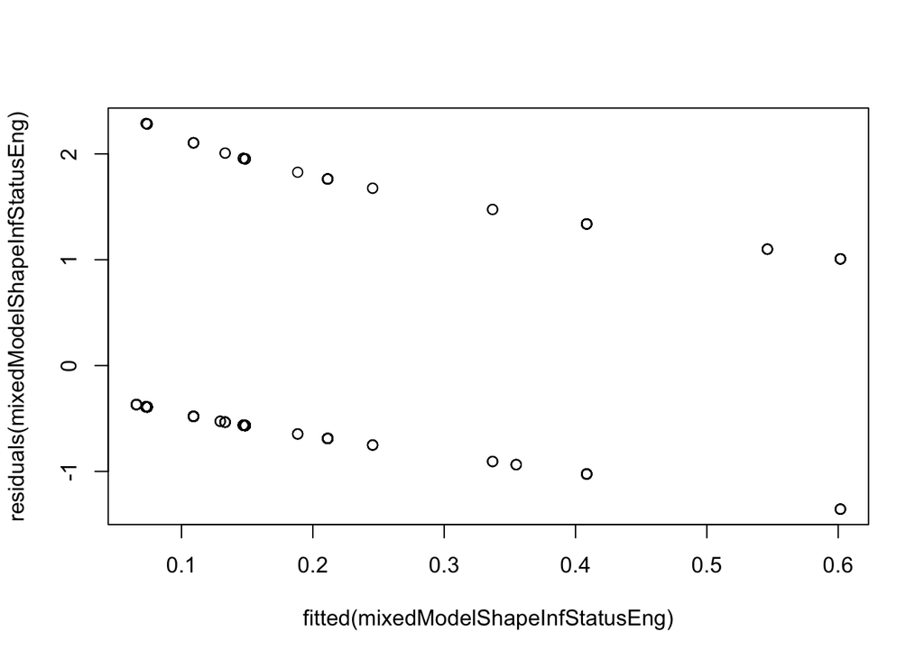

```r
# Significance test
prob.disp <- pchisq(rdev, rdf, lower.tail=FALSE, log.p=TRUE)

plot(fitted(mixedModelShapeInfStatusEng), residuals(mixedModelShapeInfStatusEng))
```

## Subset Russian data for hand shape variable (index or palm)

```r
shapeDataRus <- cleanDataForAnalysis %>%
  filter(infstat!= "other") %>%
  filter(lang=="rus") %>%
  filter(shape!="other") %>%
  filter(speaker!="FPPTRR105") %>%
  select(speaker, shape, infstat)
```

## Fixed-effects minimal base-line model vs a base-line mixed-model using the glmer function with a random intercept for speaker

AIC of the glmer model is smaller than the AIC of the glm model, indicating that including random intercepts is justified.

```r
# baseline model glm
baseModelShapeRus <- glm(shape ~ 1, family = binomial, data = shapeDataRus)
# base-line mixed-model
mixedModelShapeSpeakerRus <- glmer(shape ~ (1|speaker), data = shapeDataRus, family = binomial())

AIC(baseModelShapeRus, mixedModelShapeSpeakerRus)
```

```
##                           df      AIC
## baseModelShapeRus          1 652.7614
## mixedModelShapeSpeakerRus  2 589.1090
```

## Model and summary

```r
mixedModelShapeInfStatusSpeakerRus <- glmer(shape ~ infstat + (1|speaker), data = shapeDataRus, family = binomial())

# Extract the variance-covariance matrix of the random effects
VarCorr_matrix <- VarCorr(mixedModelEffortInfStatusSpeakerRus)

# The residual variance is typically the value associated with the residual term
sigma_squared <- attr(VarCorr_matrix, "sc")^2

summary(mixedModelShapeInfStatusSpeakerRus)
```

```
## Generalized linear mixed model fit by maximum likelihood (Laplace
##   Approximation) [glmerMod]
##  Family: binomial  ( logit )
## Formula: shape ~ infstat + (1 | speaker)
##    Data: shapeDataRus
##
##      AIC      BIC   logLik deviance df.resid
##    591.0    604.0   -292.5    585.0      567
##
## Scaled residuals:
##     Min      1Q  Median      3Q     Max
## -1.2574 -0.7003 -0.3089  0.7640  3.3693
##
## Random effects:
##  Groups  Name        Variance Std.Dev.
##  speaker (Intercept) 2.373    1.541
## Number of obs: 570, groups:  speaker, 6
##
## Fixed effects:
##             Estimate Std. Error z value Pr(>|z|)
## (Intercept) -1.26779    0.66887  -1.895    0.058 .
## infstatold  -0.08027    0.20689  -0.388    0.698
## ---
## Signif. codes:  0 '***' 0.001 '**' 0.01 '*' 0.05 '.' 0.1 ' ' 1
##
## Correlation of Fixed Effects:
##            (Intr)
## infstatold -0.129
```

```r
sjPlot::tab_model(mixedModelShapeInfStatusSpeakerRus)
```

|  | shape |  |  |
| --- | --- | --- | --- |
| Predictors | Odds Ratios | CI | p |
| (Intercept) | 0.28 | 0.08 – 1.04 | 0.058 |
| infstat [old] | 0.92 | 0.62 – 1.38 | 0.698 |
| Random Effects |  |  |  |
| σ<sup>2</sup> | 3.29 |  |  |
| τ<sub>00</sub> <sub>speaker</sub> | 2.37 |  |  |
| ICC | 0.42 |  |  |
| N <sub>speaker</sub> | 6 |  |  |
| Observations | 570 |  |  |
| Marginal R<sup>2</sup> / Conditional R<sup>2</sup> | 0.000 / 0.419 |  |  |

## Subset and fit Idi model for pointing gesture hand shape

```r
modelShapeInfStatusIdi <- glm(shape ~ infstat, data = phaseDataIdi, family = "binomial")

summary(modelShapeInfStatusIdi)
```

```
##
## Call:
## glm(formula = shape ~ infstat, family = "binomial", data = phaseDataIdi)
##
## Coefficients:
##             Estimate Std. Error z value Pr(>|z|)
## (Intercept)  -2.7850     0.4608  -6.044 1.51e-09 ***
## infstatold   -0.4731     0.7473  -0.633    0.527
## ---
## Signif. codes:  0 '***' 0.001 '**' 0.01 '*' 0.05 '.' 0.1 ' ' 1
##
## (Dispersion parameter for binomial family taken to be 1)
##
##     Null deviance: 64.227  on 166  degrees of freedom
## Residual deviance: 63.815  on 165  degrees of freedom
## AIC: 67.815
##
## Number of Fisher Scoring iterations: 6
```

```r
sjPlot::tab_model(modelShapeInfStatusIdi)
```

|  | shape |  |  |
| --- | --- | --- | --- |
| Predictors | Odds Ratios | CI | p |
| (Intercept) | 0.06 | 0.02 – 0.14 | **<0.001** |
| infstat [old] | 0.62 | 0.12 – 2.63 | 0.527 |
| Observations | 167 |  |  |
| R<sup>2</sup> Tjur | 0.004 |  |  |

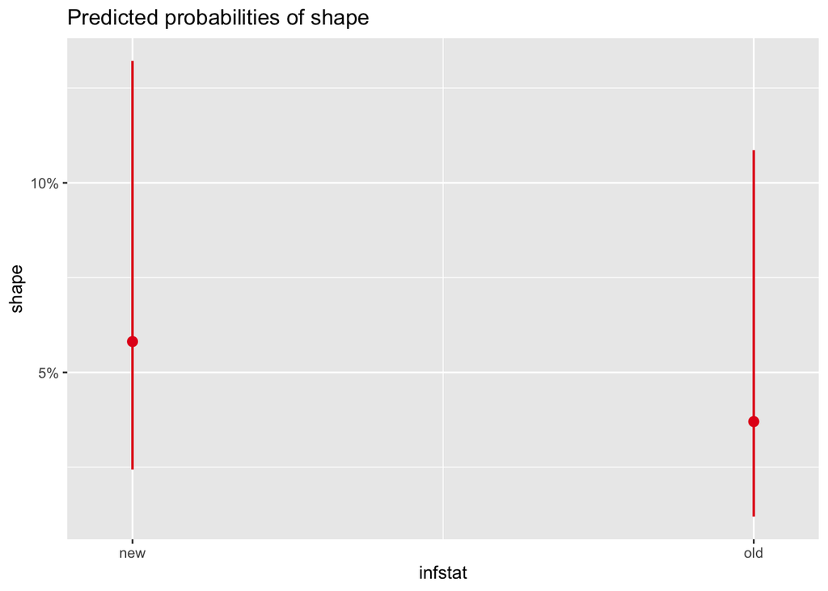

```r
plot_model(modelShapeInfStatusIdi, type = "pred", terms = "infstat")
```

## Make predicted probabilty plot for hand shape ## (index finger versus open palm poitnign gesture) in all three languages

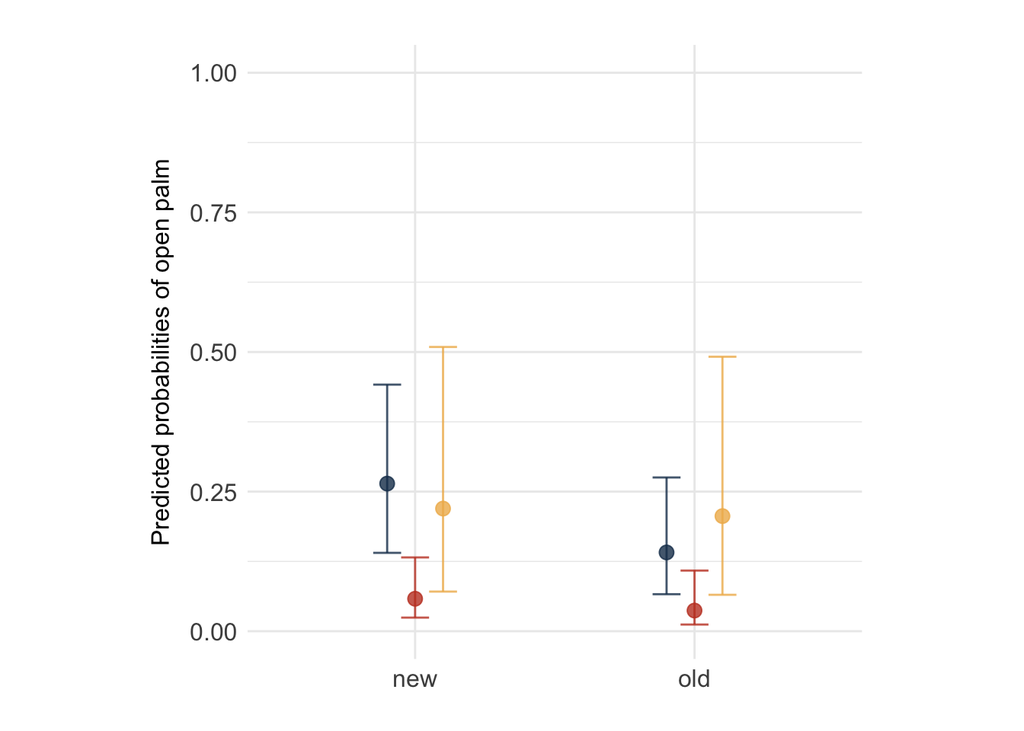

```r
plotModelShapeIdi <- ggpredict(modelShapeInfStatusIdi, "infstat") %>% as.data.frame()
plotModelShapeEng <- ggpredict(mixedModelShapeInfStatusEng, "infstat") %>% as.data.frame()
plotModelShapeRus <- ggpredict(mixedModelShapeInfStatusSpeakerRus, "infstat")%>% as.data.frame()

plotPredProbShapeEngIdiRus <- ggplot(plotModelShapeEng, aes(x, predicted)) +
  geom_errorbar(aes(ymin=conf.low, ymax=conf.high, color="#183A5A"), width=.1, alpha = 0.8,  position = position_nudge(x = -0.1)) + # English errorbar
  geom_point(aes(color="#183A5A"), size = 3, alpha = 0.8,  position = position_nudge(x = -0.1)) + # blue color
  geom_errorbar(data=plotModelShapeRus, aes(ymin=conf.low, ymax=conf.high, color="#EFB758"), width=.1, alpha = 0.8,  position = position_nudge(x = 0.1)) + # Russian errorbar
  geom_point(data=plotModelShapeRus, aes(colour = "#EFB758"), size = 3, alpha = 0.8, position = position_nudge(x = 0.1)) + # yellow color
  geom_errorbar(data=plotModelShapeIdi, aes(ymin=conf.low, ymax=conf.high, color="#C34129"), width=.1, alpha = 0.8) + # Idi errorbar
  geom_point(data=plotModelShapeIdi, aes(colour = "#C34129"), size = 3, alpha = 0.8) + # red color
  coord_cartesian(ylim=c(0, 1)) +
  theme_minimal() +
  labs(x="", y="Predicted probabilities of open palm", title = "") +
  scale_color_identity(name = "Languages:",
                          breaks = c("#183A5A", "#C34129", "#EFB758"),
                          labels = c("English", "Idi", "Russian"),
                          guide = "legend")  +
  theme(axis.title = element_text(size=12),
        axis.title.y = element_text(vjust=3),
        axis.text = element_text(size=12),
        plot.title = element_text(size=12, hjust = 0.5),
        legend.text = element_text(size=12),
        legend.title = element_text(size=12),
        aspect.ratio = 2/2,
        legend.position = "none")

plotPredProbShapeEngIdiRus
```

## Save figures for hand shape

```r
png(here("figures", "FPPT-Point-shape-thee-lang.png"), width = 7.5, height = 9, units = "cm", res = 500)
plotPredProbShapeEngIdiRus
dev.off()
```

```r
pdf(here("figures", "FPPT-Point-shape-thee-lang.pdf"),  width = 3.5, height = 4)
plotPredProbShapeEngIdiRus
dev.off()
```

## Make predicted probabilty plot for effort

## (contact with the target during the pointing gesture or absence of contact)

## in all three languages

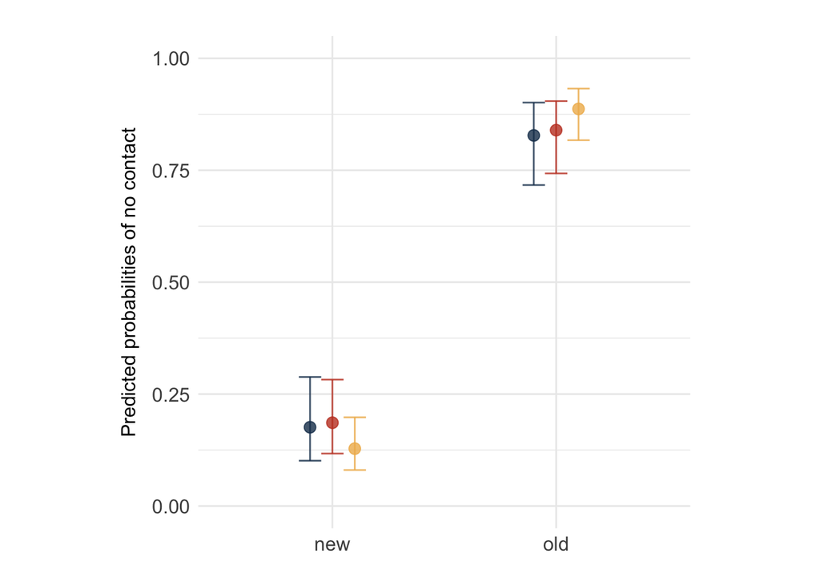

```r
plotModelEffortIdi <- ggpredict(modelEffortInfStatIdi, "infstat") %>% as.data.frame()
plotModelEffortEng <- ggpredict(mixeModelEffortInfStatSpeakerEng, "infstat") %>% as.data.frame()
plotModelEffortRus <- ggpredict(mixedModelEffortInfStatusSpeakerRus, "infstat")%>% as.data.frame()

plotPredProbEffortEngIdiRus <- ggplot(plotModelEffortEng, aes(x, predicted)) +
  geom_errorbar(aes(ymin=conf.low, ymax=conf.high, color="#183A5A"), width=.1, alpha = 0.8,  position = position_nudge(x = -0.1)) + # English errorbar
  geom_point(aes(color="#183A5A"), size = 3, alpha = 0.8,  position = position_nudge(x = -0.1)) + # blue color
  geom_errorbar(data=plotModelEffortRus, aes(ymin=conf.low, ymax=conf.high, color="#EFB758"), width=.1, alpha = 0.8,  position = position_nudge(x = 0.1)) + # Russian errorbar
  geom_point(data=plotModelEffortRus, aes(colour = "#EFB758"), size = 3, alpha = 0.8, position = position_nudge(x = 0.1)) + # yellow color
  geom_errorbar(data=plotModelEffortIdi, aes(ymin=conf.low, ymax=conf.high, color="#C34129"), width=.1, alpha = 0.8) + # Idi errorbar
  geom_point(data=plotModelEffortIdi, aes(colour = "#C34129"), size = 3, alpha = 0.8) + # red color
  coord_cartesian(ylim=c(0, 1)) +
  theme_minimal() +
  theme(aspect.ratio = 2/2) +
  labs(y="Predicted probabilities of no contact", x="", title = "") +
  scale_color_identity(name = "Languages:",
                          breaks = c("#183A5A", "#C34129", "#EFB758"),
                          labels = c("English", "Idi", "Russian"),
                          guide = "legend")  +
  theme(axis.title = element_text(size=12),
        axis.title.y = element_text(vjust=3),
        axis.text = element_text(size=12),
        plot.title = element_text(size=12, hjust = 0.5),
        legend.text = element_text(size=12),
        legend.title = element_text(size=12),
        aspect.ratio = 2/2,
        legend.position = "none")

plotPredProbEffortEngIdiRus
```

## Save figures for contact

```r
png(here("figures", "FPPT-Point-cont-thee-lang.png"), width = 10, height = 9, units = "cm", res = 500)
plotPredProbEffortEngIdiRus
dev.off()
```

```r
pdf(here("figures", "FPPT-Point-cont-thee-lang.pdf"),  width = 3.5, height = 4)
plotPredProbEffortEngIdiRus
dev.off()
```

## Pointing gesture rates and common ground

## Load and clean the human referents data

```r
rawHumanReferentsData <- read.csv(here("data", "FPPT-ER-HumRef-Annotations.csv"), na.strings=c(""," ","NA", "na"))

cleanDataHumanReferentsEngRus <- rawHumanReferentsData %>%
  select(2,9:10) %>%
  mutate_all(function(x)gsub('\\s+', '', x)) %>% #remove all spaces in the df
  separate(V9, c("pp", "new", "point"), "-") %>% #separate Point_form into 4 columns
  rename(speaker = V2, reference = pp, infstat = new, trial = V10) %>% #rename all columns
  mutate(lang = case_when(str_detect(trial,"-ENG-") ~ "eng",
                         str_detect(trial, "-RUS-") ~ "rus",
                        TRUE ~ "idi")) %>% # create a column for language based on file name
  select(1:4,6) %>%
  mutate_if(is.character,as.factor) %>%
  arrange(lang, speaker) %>%
  drop_na()
```

## Inspect the human referents data

```r
str(cleanDataHumanReferentsEngRus)
```

```
## 'data.frame':    1479 obs. of  5 variables:
##  $ speaker  : Factor w/ 13 levels "FPPTER106","FPPTER107",..: 1 1 1 1 1 1 1 1 1 1 ...
##  $ reference: Factor w/ 4 levels "generic","pp",..: 1 4 1 4 1 1 1 4 2 2 ...
##  $ infstat  : Factor w/ 2 levels "new","old": 1 1 2 1 2 2 2 1 2 2 ...
##  $ point    : Factor w/ 2 levels "nopoint","point": 1 1 1 1 1 1 1 1 1 1 ...
##  $ lang     : Factor w/ 2 levels "eng","rus": 1 1 1 1 1 1 1 1 1 1 ...
```

```r
summary(cleanDataHumanReferentsEngRus)
```

```
##       speaker       reference   infstat       point      lang
##  FPPTER107:248   generic :275   new:628   nopoint:987   eng:807
##  FPPTRR303:182   pp      :834   old:851   point  :492   rus:672
##  FPPTER201:161   pro     : 50
##  FPPTRR105:131   specific:320
##  FPPTRR202:107
##  FPPTRR307:107
##  (Other)  :543
```

## Generate and explore English df

```r
dataHumanReferentsEng <- cleanDataHumanReferentsEngRus %>%
  filter(lang=="eng", reference!="pro")

table(dataHumanReferentsEng$reference,dataHumanReferentsEng$infstat)
```

```
##
##            new old
##   generic   82  49
##   pp        87 395
##   pro        0   0
##   specific 150  23
```

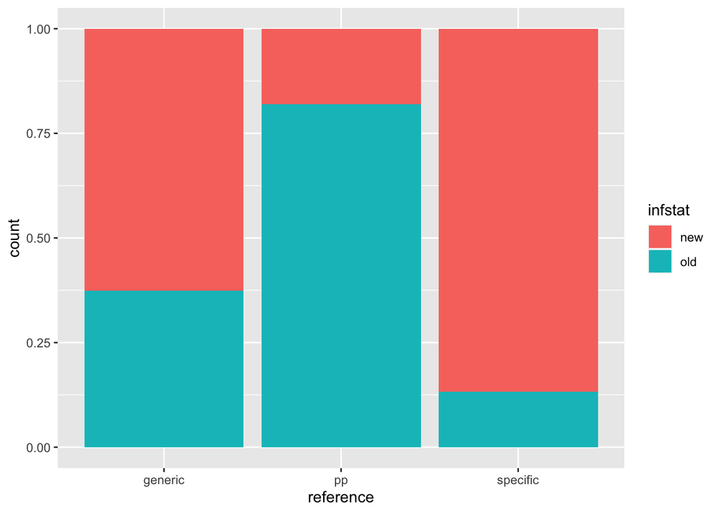

```r
ggplot(dataHumanReferentsEng, aes(x = reference, fill = infstat)) + geom_bar(position = "fill")
```

## English model for poinitng gesture occurence The model with interaction has lower AIC and BIC values and the R² values (both conditional and marginal) are higher for model with interaction, indicating it explains more variance than the model without.

```r
# Model for poiting occurence based on referring expression only
mixedModelPointRefExprEng <- glmer(point ~ reference + (1 | speaker), data =dataHumanReferentsEng, family = "binomial")

# Simple model without interaction with reffering expression and information status
mixedModelPointRefExprInfStatEng <- glmer(point ~ reference + infstat + (1 | speaker), data =dataHumanReferentsEng, family = "binomial")

# Model with interaction
mixedModelPointInteractionEng <- glmer(point ~ reference + infstat * reference + (1 | speaker), data =dataHumanReferentsEng, family = "binomial")

compare_performance(mixedModelPointRefExprEng, mixedModelPointInteractionEng)
```

```
## # Comparison of Model Performance Indices
##
## Name                          |    Model | AIC (weights) | AICc (weights) | BIC (weights) | R2 (cond.) | R2 (marg.) |   ICC |  RMSE | Sigma | Log_loss | Score_log | Score_spherical
## ------------------------------------------------------------------------------------------------------------------------------------------------------------------------------------
## mixedModelPointRefExprEng     | glmerMod | 821.7 (<.001) |  821.8 (<.001) | 840.4 (<.001) |      0.291 |      0.094 | 0.217 | 0.407 | 1.000 |    0.502 |   -83.825 |           0.007
## mixedModelPointInteractionEng | glmerMod | 535.4 (>.999) |  535.5 (>.999) | 568.1 (>.999) |      0.607 |      0.478 | 0.247 | 0.308 | 1.000 |    0.318 |      -Inf |           0.011
```

```r
anova(mixedModelPointRefExprInfStatEng, mixedModelPointInteractionEng)
```

```
## Data: dataHumanReferentsEng
## Models:
## mixedModelPointRefExprInfStatEng: point ~ reference + infstat + (1 | speaker)
## mixedModelPointInteractionEng: point ~ reference + infstat * reference + (1 | speaker)
##                                  npar    AIC    BIC  logLik deviance  Chisq Df
## mixedModelPointRefExprInfStatEng    5 606.71 630.04 -298.35   596.71
## mixedModelPointInteractionEng       7 535.40 568.07 -260.70   521.40 75.304  2
##                                  Pr(>Chisq)
## mixedModelPointRefExprInfStatEng
## mixedModelPointInteractionEng     < 2.2e-16 ***
## ---
## Signif. codes:  0 '***' 0.001 '**' 0.01 '*' 0.05 '.' 0.1 ' ' 1
```

```r
summary(mixedModelPointInteractionEng)
```

```
## Generalized linear mixed model fit by maximum likelihood (Laplace
##   Approximation) [glmerMod]
##  Family: binomial  ( logit )
## Formula: point ~ reference + infstat * reference + (1 | speaker)
##    Data: dataHumanReferentsEng
##
##      AIC      BIC   logLik deviance df.resid
##    535.4    568.1   -260.7    521.4      779
##
## Scaled residuals:
##     Min      1Q  Median      3Q     Max
## -6.8056 -0.3524 -0.2621  0.1081  8.0959
##
## Random effects:
##  Groups  Name        Variance Std.Dev.
##  speaker (Intercept) 1.077    1.038
## Number of obs: 786, groups:  speaker, 7
##
## Fixed effects:
##                              Estimate Std. Error z value Pr(>|z|)
## (Intercept)                    0.9885     0.4874   2.028   0.0426 *
## referencepp                    2.0816     0.6668   3.122   0.0018 **
## referencespecific             -2.9887     0.3755  -7.959 1.73e-15 ***
## infstatold                    -2.1715     0.4448  -4.882 1.05e-06 ***
## referencepp:infstatold        -3.7933     0.7766  -4.885 1.04e-06 ***
## referencespecific:infstatold   3.0676     0.7020   4.370 1.24e-05 ***
## ---
## Signif. codes:  0 '***' 0.001 '**' 0.01 '*' 0.05 '.' 0.1 ' ' 1
##
## Correlation of Fixed Effects:
##             (Intr) rfrncp rfrncs infstt rfrncp:
## referencepp -0.242
## refrncspcfc -0.434  0.303
## infstatold  -0.355  0.250  0.478
## rfrncpp:nfs  0.205 -0.857 -0.229 -0.553
## rfrncspcfc:  0.223 -0.159 -0.517 -0.631  0.342
```

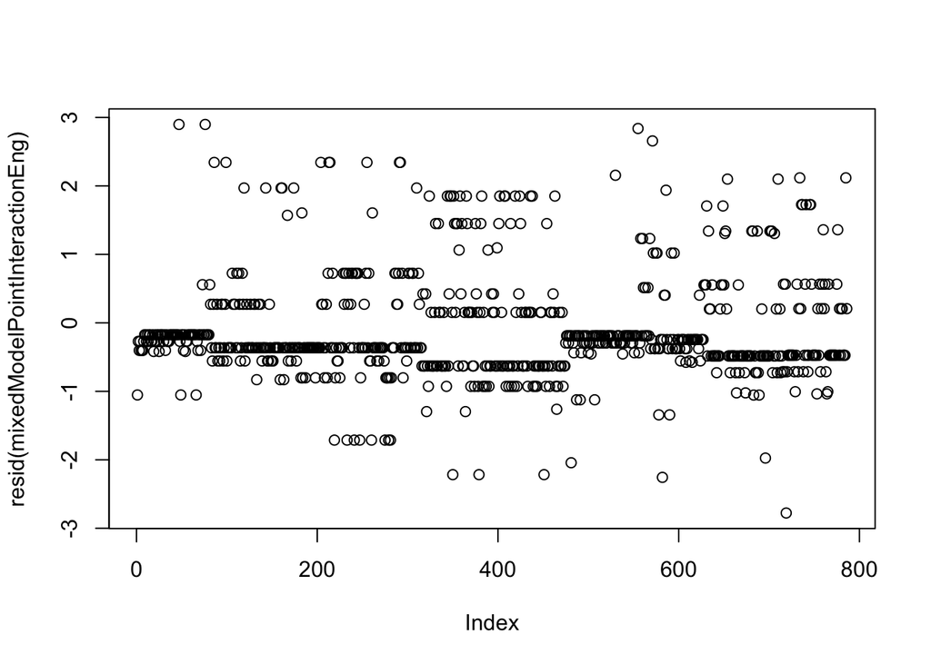

```r
plot(resid(mixedModelPointInteractionEng))
```

```r
# Manually check for convergence issues
mixedModelPointInteractionEng@optinfo$conv
```

```
## $opt
## [1] 0
##
## $lme4
## list()
```

## Russian subset for human referents and pointing gestures

```r
dataHumanReferentsRus <- cleanDataHumanReferentsEngRus %>%
  filter(lang=="rus", reference!="pro")
```

## Russian model for poinitng gesture occurence

```r
# Model for poiting occurence based on referring expression only
mixedModelPointRefExprRus <- glmer(point ~ reference + (1 | speaker), data =dataHumanReferentsRus, family = "binomial")

# Simple model without interaction
mixedModelPointRefExprInfStatRus <- glmer(point ~ reference + infstat + (1 | speaker), data =dataHumanReferentsRus, family = "binomial")

# Model with interaction
mixedModelPointInteractionRus <- glmer(point ~ reference + infstat * reference + (1 | speaker), data =dataHumanReferentsRus, family = "binomial")

summary(mixedModelPointInteractionRus)
```

```
## Generalized linear mixed model fit by maximum likelihood (Laplace
##   Approximation) [glmerMod]
##  Family: binomial  ( logit )
## Formula: point ~ reference + infstat * reference + (1 | speaker)
##    Data: dataHumanReferentsRus
##
##      AIC      BIC   logLik deviance df.resid
##    501.4    532.7   -243.7    487.4      636
##
## Scaled residuals:
##     Min      1Q  Median      3Q     Max
## -8.5761 -0.3645 -0.3508  0.2900  2.9064
##
## Random effects:
##  Groups  Name        Variance Std.Dev.
##  speaker (Intercept) 0.01289  0.1135
## Number of obs: 643, groups:  speaker, 6
##
## Fixed effects:
##                              Estimate Std. Error z value Pr(>|z|)
## (Intercept)                    2.4222     0.3980   6.086 1.16e-09 ***
## referencepp                    1.8739     1.0820   1.732 0.083313 .
## referencespecific             -3.4369     0.4468  -7.692 1.45e-14 ***
## infstatold                    -3.2187     0.4866  -6.615 3.71e-11 ***
## referencepp:infstatold        -3.1495     1.1348  -2.776 0.005512 **
## referencespecific:infstatold   2.5382     0.7584   3.347 0.000817 ***
## ---
## Signif. codes:  0 '***' 0.001 '**' 0.01 '*' 0.05 '.' 0.1 ' ' 1
##
## Correlation of Fixed Effects:
##             (Intr) rfrncp rfrncs infstt rfrncp:
## referencepp -0.362
## refrncspcfc -0.878  0.324
## infstatold  -0.805  0.296  0.718
## rfrncpp:nfs  0.345 -0.953 -0.308 -0.429
## rfrncspcfc:  0.517 -0.190 -0.586 -0.641  0.275
```

```r
sjPlot::tab_model(mixedModelPointInteractionRus)
```

|  | point |  |  |
| --- | --- | --- | --- |
| Predictors | Odds Ratios | CI | p |
| (Intercept) | 11.27 | 5.17 – 24.59 | **<0.001** |
| reference [pp] | 6.51 | 0.78 – 54.31 | 0.083 |
| reference [specific] | 0.03 | 0.01 – 0.08 | **<0.001** |
| infstat [old] | 0.04 | 0.02 – 0.10 | **<0.001** |
| reference [pp] × infstat [old] | 0.04 | 0.00 – 0.40 | **0.006** |
| reference [specific] × infstat [old] | 12.66 | 2.86 – 55.96 | **0.001** |
| Random Effects |  |  |  |
| σ<sup>2</sup> | 3.29 |  |  |
| τ<sub>00</sub> <sub>speaker</sub> | 0.01 |  |  |
| ICC | 0.00 |  |  |
| N <sub>speaker</sub> | 6 |  |  |
| Observations | 643 |  |  |
| Marginal R<sup>2</sup> / Conditional R<sup>2</sup> | 0.601 / 0.602 |  |  |

```r
compare_performance(mixedModelPointRefExprInfStatRus, mixedModelPointInteractionRus)
```

```
## # Comparison of Model Performance Indices
##
## Name                             |    Model | AIC (weights) | AICc (weights) | BIC (weights) | R2 (cond.) | R2 (marg.) |   ICC |  RMSE | Sigma | Log_loss | Score_log | Score_spherical
## ---------------------------------------------------------------------------------------------------------------------------------------------------------------------------------------
## mixedModelPointRefExprInfStatRus | glmerMod | 528.8 (<.001) |  528.9 (<.001) | 551.2 (<.001) |      0.552 |      0.551 | 0.003 | 0.343 | 1.000 |    0.402 |  -192.770 |           0.008
## mixedModelPointInteractionRus    | glmerMod | 501.4 (>.999) |  501.6 (>.999) | 532.7 (>.999) |      0.602 |      0.601 | 0.004 | 0.339 | 1.000 |    0.378 |      -Inf |           0.008
```

```r
anova(mixedModelPointRefExprInfStatRus, mixedModelPointInteractionRus)
```

```
## Data: dataHumanReferentsRus
## Models:
## mixedModelPointRefExprInfStatRus: point ~ reference + infstat + (1 | speaker)
## mixedModelPointInteractionRus: point ~ reference + infstat * reference + (1 | speaker)
##                                  npar    AIC    BIC  logLik deviance  Chisq Df
## mixedModelPointRefExprInfStatRus    5 528.85 551.18 -259.42   518.85
## mixedModelPointInteractionRus       7 501.43 532.69 -243.72   487.43 31.415  2
##                                  Pr(>Chisq)
## mixedModelPointRefExprInfStatRus
## mixedModelPointInteractionRus     1.508e-07 ***
## ---
## Signif. codes:  0 '***' 0.001 '**' 0.01 '*' 0.05 '.' 0.1 ' ' 1
```

## Plot predicted probabilites based on models for English and Russian

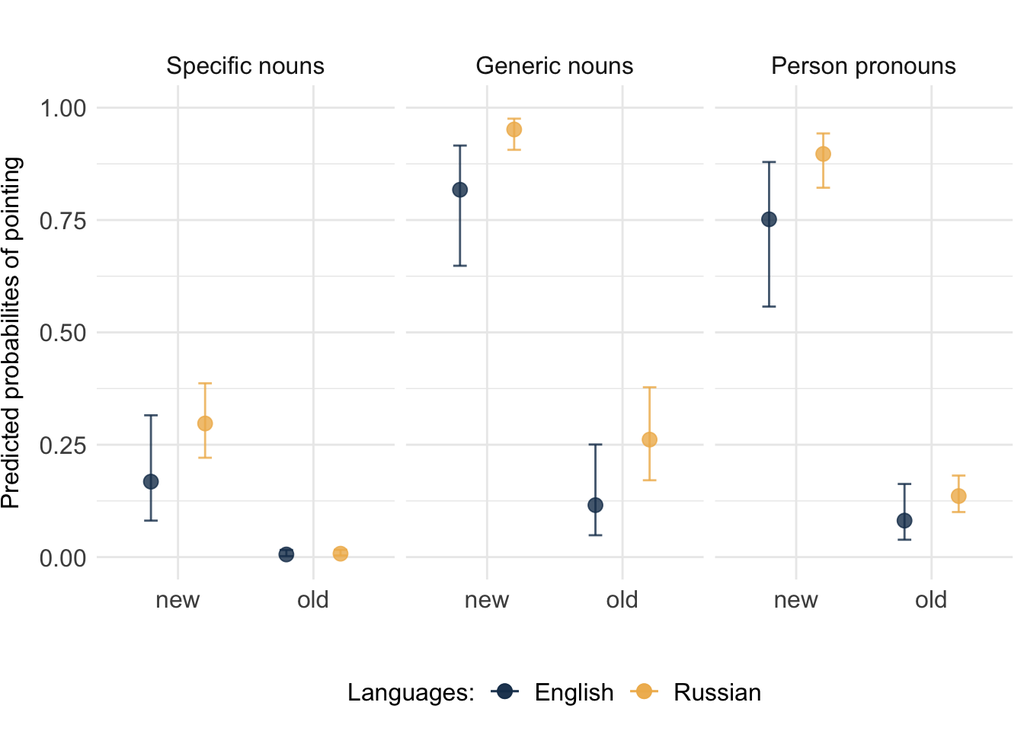

```r
plotModelPointOccEng <- ggpredict(mixedModelPointRefExprInfStatEng, terms = c("reference", "infstat")) %>% as.data.frame()
plotModelPointOccRus <- ggpredict(mixedModelPointRefExprInfStatRus, terms = c("reference", "infstat"))%>% as.data.frame()

referent_names <- list(
  'specific'="Specific nouns",
  'generic'="Generic nouns",
  'pp'="Person pronouns"
)
referent_labeller <- function(variable,value){
  return(referent_names[value])
}

plotPredProbPointOccEngRus <- ggplot(data = plotModelPointOccEng, aes(x=group, y=predicted)) +
  geom_errorbar(aes(ymin=conf.low, ymax=conf.high,color="#183A5A"), width=.1, alpha = 0.8,
                position=position_nudge(x=-0.2)) + # English errorbar
  geom_point(aes(color="#183A5A"), size = 3, alpha = 0.8,  position = position_nudge(x=-0.2)) +
  geom_errorbar(data = plotModelPointOccRus, aes(ymin=conf.low, ymax=conf.high, color="#EFB758"), width=.1, alpha = 0.8, position = position_nudge(x=0.2)) + # Russian errorbar
  geom_point(data = plotModelPointOccRus, aes(color="#EFB758"), size = 3, alpha = 0.8, position = position_nudge(x=0.2)) +
  facet_grid(~factor(x, levels=c('specific','generic','pp')), scales = "free", space = "free", labeller=referent_labeller) +
  coord_cartesian(ylim=c(0, 1)) +
  theme_minimal() +
  scale_color_identity(name = "Languages:",
                          breaks = c("#183A5A", "#EFB758"),
                          labels = c("English", "Russian"),
                          guide = "legend") +
  labs(x="", y="Predicted probabilites of pointing", title = "",
       color="Language") +
  theme(legend.position = "bottom",
        strip.text.x = element_text(size=12),
        axis.title = element_text(size=12),
        axis.title.y = element_text(vjust=3),
        axis.text = element_text(size=12),
        plot.title = element_text(size=12, hjust = 0.5),
        legend.text = element_text(size=12),
        legend.title = element_text(size=12)) + geom_blank()
plotPredProbPointOccEngRus
```

## Save figures

```r
png(here("figures", "FPPT-Point-rates-two-lang.png"), width = 16, height = 10, units = "cm", res = 500)
plotPredProbPointOccEngRus
dev.off()
```

```r
pdf(here("figures", "FPPT-Point-rates-two-lang.pdf"), width = 6, height = 4)
plotPredProbPointOccEngRus
dev.off()
```